# Impact of Ozempic on Obese and Hypertensive Patients

## Team Members: Colin Chen, Jessica Yang, Sreeja Macha

# **1. Exploratory Data Analysis (EDA)**

- Conduct a thorough exploration of the provided datasets. This includes understanding the structure, identifying missing values, and summarizing key statistics.
- Generate visualizations to understand the distribution of important variables, relationships between different variables, and any other patterns or anomalies in the data such as peculiar patterns or outliers.

```python
#Import necessary libraries for the analysis
import pandas as pd
import numpy as np
import matplotlib.pyplot as plt
import seaborn as sns
import statsmodels.api as sm
import operator

from io import BytesIO
from sklearn.model_selection import train_test_split
from sklearn.metrics import mean_squared_error, r2_score
from sklearn.preprocessing import StandardScaler, OneHotEncoder
from sklearn.linear_model import LassoCV
from sklearn.impute import SimpleImputer
from sklearn.compose import ColumnTransformer
from sklearn.pipeline import Pipeline
```

```python
# Load the Medical Claims and Precription data files
medical_claims = pd.read_csv("Medical Claims Data SMALL.csv")
prescription = pd.read_csv("Prescription Data SMALL.csv")
```

```python
# Remove 'unnamed' columns
medical_claims = medical_claims.loc[:, ~medical_claims.columns.str.contains('^Unnamed')]
prescription = prescription.loc[:, ~prescription.columns.str.contains('^Unnamed')]
```

```python
# View high-level information about the data
medical_claims.info()
```

```
<class 'pandas.core.frame.DataFrame'>
RangeIndex: 623525 entries, 0 to 623524
Data columns (total 34 columns):
 #   Column             Non-Null Count   Dtype
---  ------             --------------   -----
 0   journey_id         623525 non-null  object
 1   episode_id         623525 non-null  object
 2   visit_id           621650 non-null  object
 3   encounter_id       623525 non-null  object
 4   claim_date         623525 non-null  object
 5   patient_state      623525 non-null  object
 6   patient_short_zip  623512 non-null  float64
 7   patient_age        616980 non-null  float64
 8   patient_gender     623393 non-null  object
 9   place_of_service   484555 non-null  object
```

[output cut: 26 more lines]

```python
# Filter for rows with proc_code = 'J3490' (implies administration of Ozempic)
filtered_medical_claims = medical_claims[medical_claims['proc_code'] == "J3490"]
```

```python
# View high-level information about the Ozempic medical claims data
filtered_medical_claims.info()
```

```
<class 'pandas.core.frame.DataFrame'>
Index: 772 entries, 216 to 622748
Data columns (total 34 columns):
 #   Column             Non-Null Count  Dtype
---  ------             --------------  -----
 0   journey_id         772 non-null    object
 1   episode_id         772 non-null    object
 2   visit_id           772 non-null    object
 3   encounter_id       772 non-null    object
 4   claim_date         772 non-null    object
 5   patient_state      772 non-null    object
 6   patient_short_zip  772 non-null    float64
 7   patient_age        750 non-null    float64
 8   patient_gender     772 non-null    object
 9   place_of_service   203 non-null    object
```

[output cut: 26 more lines]

```python
# View high-level information about the precription data
prescription.info()
```

```
<class 'pandas.core.frame.DataFrame'>
RangeIndex: 894623 entries, 0 to 894622
Data columns (total 48 columns):
 #   Column                         Non-Null Count   Dtype
---  ------                         --------------   -----
 0   journey_id                     894623 non-null  object
 1   cohort_id                      894623 non-null  int64
 2   claim_id                       894623 non-null  object
 3   patient_gender                 894623 non-null  object
 4   patient_state                  894623 non-null  object
 5   patient_zip                    894501 non-null  float64
 6   patient_dob                    894619 non-null  object
 7   pharmacy_npi                   839958 non-null  float64
 8   pharmacist_npi                 21578 non-null   float64
 9   prescriber_npi                 891155 non-null  object
```

[output cut: 40 more lines]

```python
## Explore the diagnosis data from Medical Claims

# Select the 'diag_list' column from 'medical_claims'
diag_columns = [col for col in medical_claims[['diag_list']]]
medical_claims_diag = medical_claims[diag_columns]

# Select the first 5 diags from 'diag_list'
combined_list = medical_claims_diag.values.flatten().tolist()
combined_list = [x for x in combined_list if pd.notna(x)]
combined_list = [','.join(item.split(',')[:5]) for item in combined_list]

# Process the first three digits
first_three_counts = {}
for diag_code in combined_list:
    first_three = diag_code[:3]
    first_three_counts[first_three] = first_three_counts.get(first_three, 0) + 1
```

```python
# Sort by item count in descending
sorted_counts = sorted(first_three_counts.items(), key=operator.itemgetter(1), reverse=True)

# Print the sorted diagnoses
for items in sorted_counts:
    print(items)
```

```
('E11', 67763)
('I10', 43637)
('Z00', 41090)
('M54', 15013)
('M25', 14575)
('E78', 13666)
('Z01', 10971)
('R07', 9773)
('G47', 9698)
('R10', 9541)
('Z12', 9168)
('N18', 8588)
('M17', 7358)
('N39', 6350)
('M79', 6232)
('E66', 5882)
('Z20', 5231)
('R73', 4732)
('Z13', 4583)
('D64', 4535)
('R06', 4306)
('R68', 4147)
('U07', 4049)
('E03', 3735)
('A41', 3734)
('I25', 3688)
('J44', 3667)
('R53', 3513)
('E55', 3511)
('Z68', 3432)
('Z23', 3133)
('I48', 3090)
('Z79', 3015)
('Z71', 2843)
('R05', 2780)
('F33', 2780)
('M47', 2755)
('Z76', 2734)
('I50', 2720)
('I11', 2580)
```

[output cut: 1141 more lines]

```
('C06', 1)
('H73', 1)
('S68', 1)
('L88', 1)
('Z70', 1)
('A42', 1)
('O01', 1)
('Q65', 1)
('M49', 1)
('D01', 1)
('A31', 1)
('H80', 1)
('O28', 1)
('J05', 1)
('I06', 1)
```

# TOP 5 ICD-10-CM Diagnosis Codes:

1. E11 corresponds to "Type 2 diabetes mellitus"
2. I10 corresponds to "Essential (primary) hypertension"
3. Z00 corresponds to "Encounter for general examination without complaint, suspected or reported diagnosis"
4. M54 corresponds to "Dorsalgia" (refers to pain in the back)
5. M25 corresponds to "Other joint disorder, not elsewhere classified"

[figure not shown]

```python
# Extract the labels and their values
labels = [item[0] for item in sorted_counts]
values = [item[1] for item in sorted_counts]

# Create a bar chart
plt.bar(labels, values)

# Add labels and title
plt.xlabel("First Three Digits of Diagnosis Codes in diag1-5")
plt.ylabel("Count")
plt.title("Occurrence of Diagnosis Codes (Ranked)")

# Rotate x labels if they're long/overlapping
if len(labels) > 5:
    plt.xticks(rotation=45, ha='right')

# Adjust layout for better display
plt.tight_layout()

# Display the plot
plt.show()
```

##### We observe a highly skewed distribution of diagnosis codes, where a few codes have very high occurrences, pointing to a small number of diagnoses that are vastly more common than others in the dataset. This pattern reflects a concentration of common conditions in the patient population.

```python
## Explore the diagnosis data from Medical Claims

# Select the 'diag_list' column from 'filtered_medical_claims'
filtered_diag_columns = [col for col in filtered_medical_claims[['diag_list']]]
filtered_medical_claims_diag = filtered_medical_claims[filtered_diag_columns]

# Select the first 5 diags from 'diag_list'
filtered_combined_list = filtered_medical_claims_diag.values.flatten().tolist()
filtered_combined_list = [x for x in filtered_combined_list if pd.notna(x)]
filtered_combined_list = [','.join(item.split(',')[:5]) for item in filtered_combined_list]

# Process the first three digits
filtered_first_three_counts = {}
for diag_code in filtered_combined_list:
    filtered_first_three = diag_code[:3]
    filtered_first_three_counts[filtered_first_three] = filtered_first_three_counts.get(filtered_first_three, 0) + 1

filtered_sorted_counts = sorted(filtered_first_three_counts.items(), key=operator.itemgetter(1), reverse=True)

# Display the items and their counts
for items in filtered_sorted_counts:
    print(items)
```

```
('N18', 42)
('E11', 34)
('I25', 31)
('Z51', 27)
('M54', 26)
('R07', 24)
('R10', 18)
('H25', 15)
('Z30', 14)
('G89', 14)
('J45', 13)
('M17', 12)
('M19', 12)
('M25', 11)
('I48', 11)
('F33', 11)
('M48', 10)
('M47', 9)
('J20', 9)
('C50', 9)
('I10', 9)
('M70', 8)
('J44', 8)
('R94', 7)
('N20', 7)
('R51', 6)
('M16', 6)
('D50', 6)
('K29', 6)
('J30', 6)
('C61', 6)
('K40', 6)
('L02', 6)
('M53', 5)
('R06', 5)
('L72', 5)
('K42', 5)
('E78', 5)
('N13', 5)
('I49', 4)
```

[output cut: 152 more lines]

```
('R80', 1)
('D24', 1)
('C90', 1)
('G06', 1)
('M18', 1)
('M89', 1)
('N49', 1)
('G56', 1)
('R91', 1)
('N43', 1)
('C84', 1)
('J38', 1)
('N65', 1)
('D17', 1)
('D05', 1)
```

# TOP 7 ICD-10-CM Diagnosis Codes for Ozempic Users

1. N18: Chronic kidney disease (CKD)
2. E11: Type 2 diabetes mellitus
3. I25: Chronic ischemic heart disease
4. Z51: Encounter for other aftercare and medical care
5. M54: Dorsalgia
6. R07: Pain in throat and chest
7. R10: Abdominal and pelvic pain

```python
## Explore the 'patient_short_zip' column

# Select the 'patient_short_zip' column from 'medical_claims'
medical_claims_zip = medical_claims['patient_short_zip']

# Combine the values
combined_list_zip = medical_claims_zip.values.flatten().tolist()
combined_list_zip = [x for x in combined_list_zip if pd.notna(x)]

# Process the first three digits
zips = {}
for diag_code in combined_list_zip:
    zips[diag_code] = zips.get(diag_code, 0) + 1
```

```python
# Sort the items by count in descending order
sorted_counts_zip = sorted(zips.items(), key=operator.itemgetter(1), reverse=True)

# Print the items and their counts
for items in sorted_counts_zip:
    print(items)
```

```
(900.0, 180469)
(922.0, 166422)
(908.0, 55562)
(921.0, 51190)
(910.0, 48395)
(913.0, 34571)
(912.0, 34143)
(911.0, 32244)
(853.0, 6499)
(857.0, 2952)
(852.0, 2399)
(864.0, 1480)
(856.0, 1456)
(350.0, 1259)
(351.0, 637)
(352.0, 530)
(863.0, 495)
(859.0, 447)
(855.0, 430)
(995.0, 370)
(996.0, 359)
(860.0, 311)
(997.0, 291)
(344.0, 58)
(194.0, 42)
(850.0, 39)
(272.0, 33)
(891.0, 32)
(923.0, 25)
(304.0, 25)
(998.0, 23)
(320.0, 22)
(91.0, 22)
(629.0, 18)
(606.0, 18)
(770.0, 17)
(105.0, 15)
(787.0, 12)
(841.0, 12)
(895.0, 9)
```

[output cut: 38 more lines]

```
(925.0, 1)
(610.0, 1)
(495.0, 1)
(321.0, 1)
(427.0, 1)
(616.0, 1)
(426.0, 1)
(600.0, 1)
(928.0, 1)
(800.0, 1)
(322.0, 1)
(315.0, 1)
(604.0, 1)
(753.0, 1)
(101.0, 1)
```

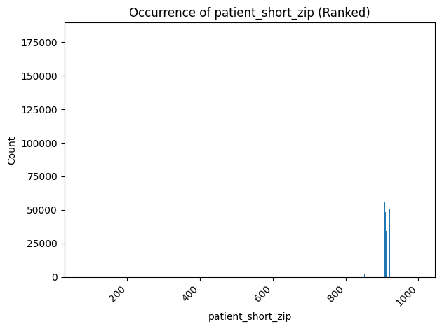

```python
# Extract the labels and their values
labels = [item[0] for item in sorted_counts_zip]
values = [item[1] for item in sorted_counts_zip]

# Create a bar chart
plt.bar(labels, values)

# Add Labels and title to the chart
plt.xlabel("patient_short_zip")
plt.ylabel("Count")
plt.title("Occurrence of patient_short_zip (Ranked)")

# Rotate x labels if they are long or overlapping
if len(labels) > 5:
    plt.xticks(rotation=45, ha='right')

# Adjust the layout
plt.tight_layout()

# Display the plot
plt.show()
```

```python
## Explore the 'patient_short_zip' column from 'filtered_medical_claims'

# Select the 'patient_short_zip' column
filtered_medical_claims_zip = filtered_medical_claims['patient_short_zip']

# Combine values
filtered_combined_list_zip = filtered_medical_claims_zip.values.flatten().tolist()
filtered_combined_list_zip = [x for x in filtered_combined_list_zip if pd.notna(x)]

# Process first three digits
filtered_zips = {}
for diag_code in filtered_combined_list_zip:
    filtered_zips[diag_code] = filtered_zips.get(diag_code, 0) + 1

filtered_sorted_counts_zip = sorted(filtered_zips.items(), key=operator.itemgetter(1), reverse=True)

# Print the items by count
for items in filtered_sorted_counts_zip:
    print(items)
```

```
(921.0, 288)
(922.0, 140)
(908.0, 128)
(910.0, 93)
(911.0, 49)
(912.0, 47)
(853.0, 12)
(852.0, 7)
(864.0, 3)
(350.0, 2)
(857.0, 2)
(859.0, 1)
```

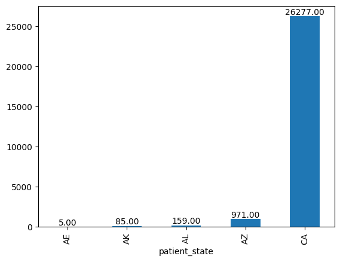

```python
# Check the number of patients' states
patient_state_cnt = medical_claims.groupby('patient_state')['journey_id'].nunique()

# Plot a bar plot
patient_state_cnt.plot.bar()
for i, v in enumerate(patient_state_cnt):
    plt.text(i, v, f'{v:.2f}', ha='center', va='bottom')

# Display the plot
plt.show()
```

```python
# Filter for claims that are relevant to Obesity
medical_claims_obesity = medical_claims[
      medical_claims['diag_1'].str.startswith("E66")|
      medical_claims['diag_2'].str.startswith("E66")|
      medical_claims['diag_3'].str.startswith("E66")|
      medical_claims['diag_4'].str.startswith("E66")|
      medical_claims['diag_5'].str.startswith("E66")
      ]
```

```python
# Add a new column 'diag' to the data-frame and set it to 'Obesity'
medical_claims_obesity['diag'] = "Obesity"
medical_claims_obesity.info()
```

```
<class 'pandas.core.frame.DataFrame'>
Index: 63026 entries, 22 to 623506
Data columns (total 35 columns):
 #   Column             Non-Null Count  Dtype
---  ------             --------------  -----
 0   journey_id         63026 non-null  object
 1   episode_id         63026 non-null  object
 2   visit_id           62900 non-null  object
 3   encounter_id       63026 non-null  object
 4   claim_date         63026 non-null  object
 5   patient_state      63026 non-null  object
 6   patient_short_zip  63018 non-null  float64
 7   patient_age        62224 non-null  float64
 8   patient_gender     63023 non-null  object
 9   place_of_service   50211 non-null  object
```

[output cut: 27 more lines]

```python
# Breakdown of patient counts based on diagnosis  and patient gender
patients_gender_cnt = medical_claims_obesity.groupby(['diag', 'patient_gender'])['journey_id'].nunique().reset_index(name = 'count')
total_cnt = patients_gender_cnt.groupby('diag')['count'].transform('sum')
patients_gender_cnt['gender_ratio'] = patients_gender_cnt['count']/total_cnt
patients_gender_cnt
```

|  | diag | patient_gender | count | gender_ratio |
| --- | --- | --- | --- | --- |
| 0 | Obesity | F | 6422 | 0.587235 |
| 1 | Obesity | M | 4514 | 0.412765 |

```python
# Find the #missing values for each column in the 'medical_claims' data-frame
medical_claims_missing_values_count = medical_claims.isna().sum()
print("Number of missing values for each column is:\n",medical_claims_missing_values_count, '\nA lot of features have abnormally high missing values.')
```

```
Number of missing values for each column is:
 journey_id                0
episode_id                0
visit_id               1875
encounter_id              0
claim_date                0
patient_state             0
patient_short_zip        13
patient_age            6545
patient_gender          132
place_of_service     138970
visit_type            23071
payor                 14589
payor_channel         37439
ref_npi              326024
hcp_npi              188872
hcp_taxonomy         195316
hcp_specialty        195296
hco_npi                5736
hcp_npi_list         188872
hco_npi_list           5736
diag_list               870
diag_1                  870
diag_2               162930
diag_3               258241
diag_4               325292
diag_5               418509
rev_center_code      509599
rev_center_units       1967
proc_code             23913
proc_modifier        457577
proc_units             2194
line_charge               0
claim_charge              0
smart_allowed             0
dtype: int64
A lot of features have abnormally high missing values.
```

```python
# Find the #missing values for each column in the 'prescription' data-frame
prescription_missing_values_count = prescription.isna().sum()
print("Number of missing values for each column is:\n",prescription_missing_values_count, '\nA lot of features have abnormally high missing values')
```

```
Number of missing values for each column is:
 journey_id                            0
cohort_id                             0
claim_id                              0
patient_gender                        0
patient_state                         0
patient_zip                         122
patient_dob                           4
pharmacy_npi                      54665
pharmacist_npi                   873045
prescriber_npi                     3468
primary_care_npi                 891054
group_id                         621002
date_of_service                       0
date_authorized                  109947
transaction_type                      0
date_prescription_written             0
ndc11                                 0
ndc11_original                   800420
number_of_refills_authorized      45104
diagnosis_code                   719918
diagnosis_code_type              782989
quantity_prescribed_original     572275
quantity_dispensed                    7
place_of_service                 548426
is_service                       216300
level_of_service                 676672
fill_number                           0
days_supply                           0
unit_of_measure                  300033
daw_code                         702479
prior_authorization_type_code    885707
is_compound_drug                 110029
coupon_type                      892593
coupon_value_amount              894618
pharmacy_submitted_cost          109542
patient_pay                      292803
copay_coinsurance                483240
pcn                              118920
bin                              108383
plan_pay                         402745
reject_code_1                    707344
reject_code_3                    853371
reject_code_4                    887215
reject_code_5                    893099
ndc                                   0
active                                0
start_date                            0
end_date                         862175
dtype: int64
A lot of features have abnormally high missing values
```

# **Medical Claims Visualization**

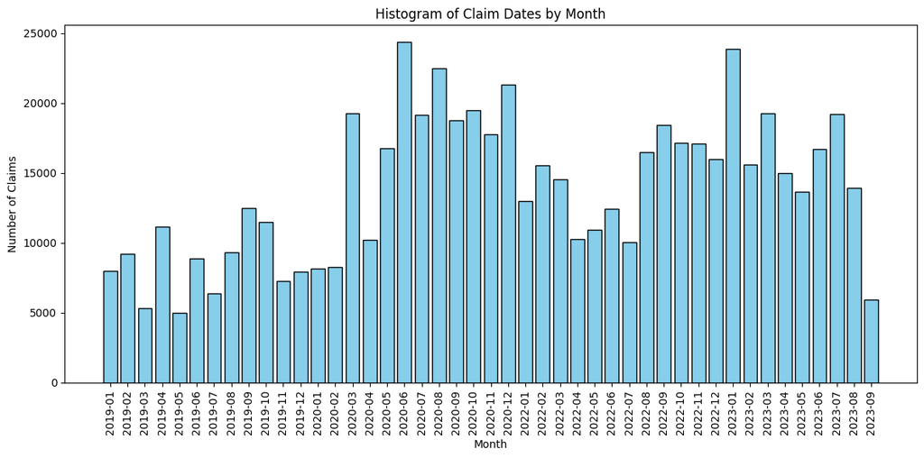

```python
## Explore 'claim_date'

# Fetch the year and month from 'claim_date' column
medical_claims['claim_date'] = pd.to_datetime(medical_claims['claim_date'])
year = medical_claims['claim_date'].dt.year
month = medical_claims['claim_date'].dt.month
medical_claims['month_year'] = medical_claims['claim_date'].dt.to_period('M')

# Count the #claims per month
claims_per_month = medical_claims['month_year'].value_counts().sort_index()

# Plot the histogram
claims_per_month.index = claims_per_month.index.to_timestamp()
plt.figure(figsize=(12, 6))
plt.bar(claims_per_month.index.strftime('%Y-%m'), claims_per_month.values, color='skyblue', edgecolor='black')
plt.title('Histogram of Claim Dates by Month')
plt.xlabel('Month')
plt.ylabel('Number of Claims')
plt.xticks(rotation=90)  # Rotate x-axis labels for better readability
plt.tight_layout()  # Adjust layout to fit x-axis labels
plt.show()
```

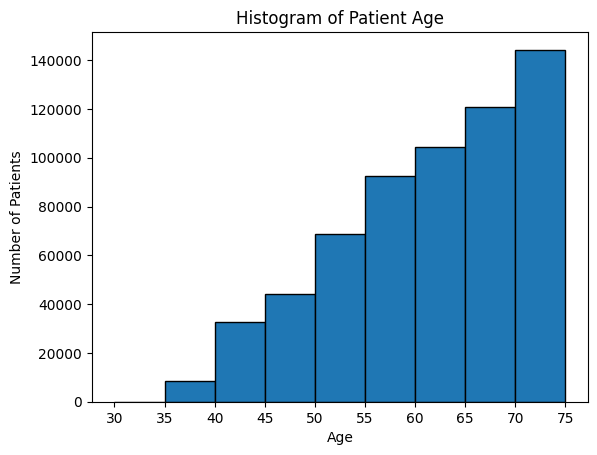

[output not shown]

```python
## Explore 'patient_age'

# Plot the histogram
plt.hist(medical_claims['patient_age'], bins=range(30, 80, 5), edgecolor='black')
plt.title('Histogram of Patient Age')
plt.xlabel('Age')
plt.ylabel('Number of Patients')
plt.xticks(range(30, 80, 5))
plt.show()

print("The histogram indicates an increasing trend in the number of patients by age group, with the highest frequency observed in the 70-75 age bracket. This suggests that the older segments of the population, particularly those approaching 75, are more frequently represented in the medical claims data, which may reflect higher healthcare needs in this age group.")
```

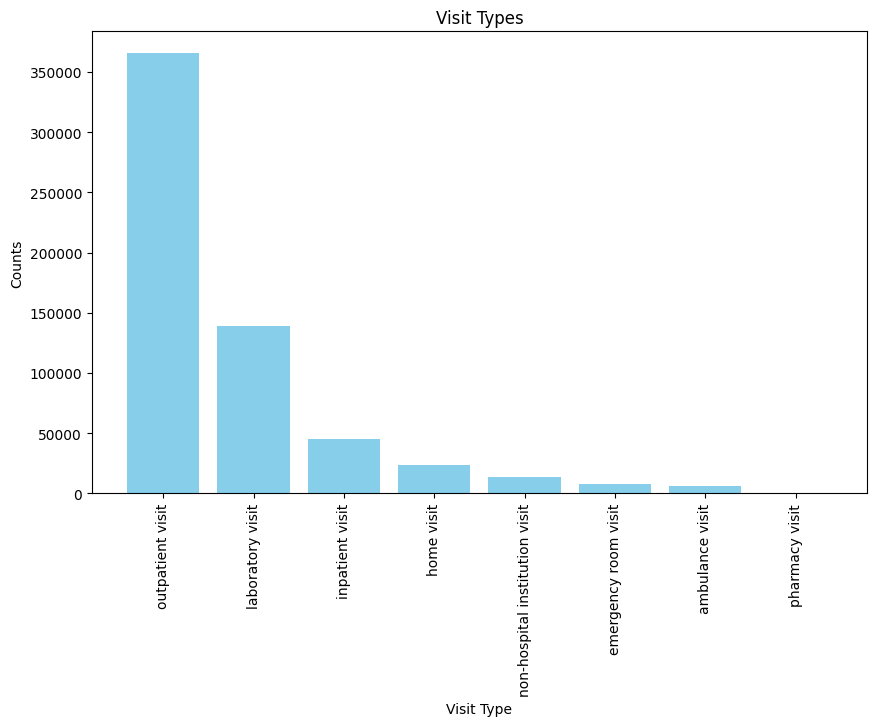

[output not shown]

```python
## Explore 'visit_type'

# Count of each 'visit_type'
visit_type_counts = medical_claims['visit_type'].value_counts()

# Sort the counts from highest to lowest
visit_type_counts_sorted = visit_type_counts.sort_values(ascending=False)

# Plot the bar chart
plt.figure(figsize=(10, 6))
plt.bar(visit_type_counts_sorted.index, visit_type_counts_sorted.values, color='skyblue')
plt.title('Visit Types')
plt.xlabel('Visit Type')
plt.ylabel('Counts')
plt.xticks(rotation=90)  # Rotate x-axis labels for better readability
plt.show()

print('The bar chart shows that most people are going to outpatient clinics, with lab visits as the next most common one. Other visit types, such as inpatient, home visits, and pharmacy visits, occur much less frequently, indicating a healthcare pattern heavily skewed towards outpatient and laboratory services.')
```

# **Prescription Visualization**

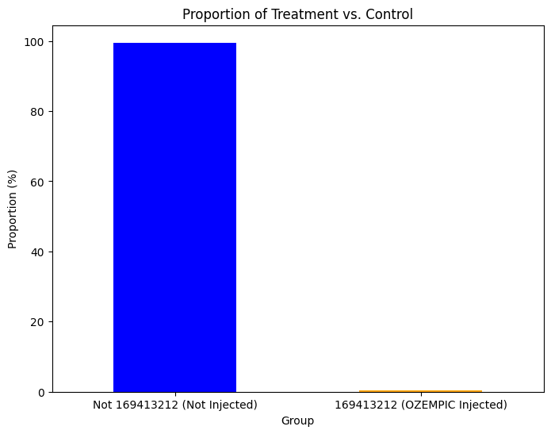

```
The Ozempic-injected group is much smaller in comparison, indicating a smaller sample size for treatment analysis.
```

```python
## Proportion of treatment vs. control.

# OZEMPIC Injected: 169413212
is_169413212 = prescription['ndc'] == 169413212
ndc_counts = is_169413212.value_counts(normalize=True).rename({True: '169413212 (OZEMPIC Injected)', False: 'Not 169413212 (Not Injected)'}) * 100

# Plot the proportions
plt.figure(figsize=(8, 6))
ndc_counts.plot(kind='bar', color=['blue', 'orange'])
plt.title('Proportion of Treatment vs. Control')
plt.xlabel('Group')
plt.ylabel('Proportion (%)')
plt.xticks(rotation=0)
plt.show()

print('The Ozempic-injected group is much smaller in comparison, indicating a smaller sample size for treatment analysis.')
```

# **2. Processing and Merging Data**

```python
## Data Processing

# Filter for patients aged between 40 and 75
medical_claims = medical_claims[(medical_claims['patient_age'] >= 40) & (medical_claims['patient_age'] <= 75)]

# Function to check whether the diag value starts with 'E66' or 'I10'
def check_values(val):
    val = str(val)
    return val.startswith('E66') or val.startswith('I10')

# Filter for obese and hypertensive patients (ICD-10CM Codes: obesity: E66; Hypertension: I10)
medical_claims = medical_claims[medical_claims[['diag_1', 'diag_2', 'diag_3', 'diag_4', 'diag_5']].applymap(check_values).any(axis=1)]
```

```python
# Extract relevant columns from 'medical_claims' data-frame:
medical_claims = medical_claims[['journey_id', 'claim_date', 'patient_short_zip', 'patient_state', 'patient_age', 'patient_gender', 'diag_1', 'diag_2', 'diag_3', 'diag_4', 'diag_5', 'visit_type', 'proc_code', 'smart_allowed']]

# Extract relevant columns from 'prescription' data-frame:
prescription = prescription[['journey_id', 'patient_gender', 'patient_state', 'date_of_service', 'ndc']]
prescription.rename(columns={'patient_gender': 'patient_gender_pre'}, inplace=True)
```

```python
# Merge the datasets via journey_id.
combined_data = pd.merge(medical_claims, prescription, on='journey_id', how='inner')

# Look at the data overview.
combined_data.info()

# Check for #missing values
combined_data.isnull().sum()

## NOTE: REST OF THE DATA CLEANING IS DONE DIRECTLY IN Q4 (before running regressions).
```

```
<class 'pandas.core.frame.DataFrame'>
RangeIndex: 7733300 entries, 0 to 7733299
Data columns (total 18 columns):
 #   Column              Dtype
---  ------              -----
 0   journey_id          object
 1   claim_date          datetime64[ns]
 2   patient_short_zip   float64
 3   patient_state_x     object
 4   patient_age         float64
 5   patient_gender      object
 6   diag_1              object
 7   diag_2              object
 8   diag_3              object
 9   diag_4              object
 10  diag_5              object
 11  visit_type          object
 12  proc_code           object
 13  smart_allowed       float64
 14  patient_gender_pre  object
 15  patient_state_y     object
 16  date_of_service     object
 17  ndc                 int64
dtypes: datetime64[ns](1), float64(3), int64(1), object(13)
memory usage: 1.0+ GB
```

```
journey_id                  0
claim_date                  0
patient_short_zip        1480
patient_state_x             0
patient_age                 0
patient_gender              0
diag_1                      0
diag_2                 310939
diag_3                 774233
diag_4                1558780
diag_5                3200128
visit_type             260878
proc_code              285420
smart_allowed               0
patient_gender_pre          0
patient_state_y             0
date_of_service             0
ndc                         0
dtype: int64
```

# **3. Causal Analysis Setup**

## Potential endogeneity issues in estimating the treatment effect of Ozempic on the target population:

##### Omitted Variable Bias: If there are unobserved variables that affect both the likelihood of receiving Ozempic (treatment) and the outcome (smart_allowed), omitting these from the analysis could lead to endogeneity. For instance, if patients with more severe health conditions are both more likely to receive Ozempic and have higher healthcare costs, failing to control for health severity could bias the treatment effect.

##### Simultaneity: If the outcome variable (smart_allowed) simultaneously influences the probability of receiving the treatment (proc_code = "J3490"), this could lead to endogeneity. For instance, if patients with higher predicted reimbursements are more likely to be prescribed Ozempic because it's more cost-effective for them.

##### Measurement Error: If there is measurement error in the independent variables, this could lead to endogeneity. For example, if patient_short_zip is inaccurately recorded, this could distort the relationship between geography and treatment effects.

##### Selection Bias: There might be a non-random selection into the treatment group. For example, if healthier or wealthier patients are more likely to be prescribed Ozempic, there might be a systematic difference between the treatment and control groups that is not captured by the observed variables.

## Strategy for addressing endogeneity:

Double Lasso Regression: It helps in variable selection and can potentially control for endogeneity by considering selected covariates based on their predictive power for the treatment and the outcome.

##### Initial Data Clean Up

1. I first filtered for obese and hypertension claims and saved them in two different data-frames. Diagnosis codes starting with 'E66' indicates 'Obese' and those that start with 'I10' indicate 'hypertension'.
2. I chose 2 categorical features 'patient_gender','visit_type' and 2 numerical features 'patient_age', 'patient_short_zip' as the covariates.
3. I encoded the categorical variables and imputed the missing values by the most frequently occuring category.
4. Imputed the numerical features by their respective means.
5. Rows with 'Proc_Code' = 'J3490' indicate treatment group, while the rest belong to the control group.
6. I chose 'smart_allowed' as the target variable.

##### Double-Lasso Regression

- Stage 1: Estimate d̂(x) with lasso regression of d on x.
1. By estimating d̂(x), we're calculating the propensity score, which predicts the likelihood of a patient being treated with Ozempic based on their characteristics (captured in the covariates).
2. With the propensity score accounting for the differences in covariates between groups, any remaining differences in outcomes can be attributed to the treatment itself, rather than confounding variables.
- Stage 2: Do a lasso of y on [d, d̂(x), x], with d̂(x) unpenalized.
1. By including the estimated treatment effects without a penalty, the model specifically accounts for the confounding variables' impact on treatment, thereby isolating the effect of the treatment on the outcome (smart_allowed).
2. This stage helps in refining causal inference.

# **4 & 5: Model Development & Evaluation**

### Justification for Variables

1. Patient Age (patient_age):

   **Rationale:**
- Age is a fundamental demographic factor that affects healthcare needs, the prevalence of certain conditions, and the likelihood of receiving various treatments. It is also associated with the complexity and cost of medical care, as older patients often require more extensive treatment.
- To control for the effects of age-related health trends and treatment patterns, which could confound the treatment effect estimation.
2. Patient Zip (patient_short_zip):

   **Rationale:**
- Geographic location can influence access to healthcare services, the prevalence of certain health conditions, and the cost structure of healthcare services due to regional pricing differences.
- Accounts for regional variations in treatment patterns and healthcare costs that could introduce bias if not controlled for.
3. Patient Gender (patient_gender):

   **Rationale:**
- Gender can influence both the likelihood of receiving certain treatments and the cost of care. For example, some medications might be prescribed more frequently to one gender due to prevalence in certain conditions, or there might be gender-based differences in healthcare-seeking behavior.
- Controls for confounding effects of gender on both treatment assignment and healthcare cost outcomes.
4. Visit Type (visit_type):

**Rationale:**

- The type of visit (outpatient, inpatient, emergency, etc.) is a strong indicator of the severity and nature of medical conditions, which can affect both the probability of being prescribed Ozempic and the resulting healthcare costs.
- Helps adjust for the intensity of medical care required, which is associated with both treatment and cost.

```python
## Split the 'medical_claim' data-frame into two subsets based on the diagnosis (obesity or hypertension)
def check_E66(val):
    val = str(val)
    return val.startswith('E66')

def check_I10(val):
    val = str(val)
    return val.startswith('I10')

# Rows with 'proc_code' = 'J3490' receive treatement and the rest are control group
medical_claims['treatment'] = medical_claims['proc_code'].apply(lambda x: 1 if x == 'J3490' else 0)

# Filter for Obesity
medical_claims_E66 = medical_claims[medical_claims[['diag_1', 'diag_2', 'diag_3', 'diag_4', 'diag_5']].map(check_E66).any(axis=1)]
medical_claims_E66 = medical_claims_E66.drop(['diag_1', 'diag_2', 'diag_3', 'diag_4', 'diag_5'], axis=1)

# Filter for Hypertension
medical_claims_I10 = medical_claims[medical_claims[['diag_1', 'diag_2', 'diag_3', 'diag_4', 'diag_5']].map(check_I10).any(axis=1)]
medical_claims_I10 = medical_claims_I10.drop(['diag_1', 'diag_2', 'diag_3', 'diag_4', 'diag_5'], axis=1)
```

```python
# To compute partial penalty
class SelectiveRegularizationLinearRegression:
    def __init__(self, alpha, apply_penalty, tolerance=1e-4, max_iterations=1000):
        self.alpha = alpha
        self.tolerance = tolerance
        self.apply_penalty = apply_penalty
        self.max_iterations = max_iterations
        self.w = None

    def _predicted_values(self, X, w):
        return np.matmul(X, w)

    def _rho_compute(self, y, X, w, j):
        X_k = np.delete(X, j, 1)
        w_k = np.delete(w, j)
        predict_k = self._predicted_values(X_k, w_k)
        residual = y - predict_k
        rho_j = np.sum(X[:, j] * residual)
        return rho_j

    def _z_compute(self, X):
        return np.sum(X * X, axis=0)

    def fit(self, X, y):
        n_samples, n_features = X.shape
        if not self.w:
            self.w = np.zeros(n_features)
        z = self._z_compute(X)
        for iteration in range(self.max_iterations):
            max_step = 0
            for j in range(n_features):
                rho_j = self._rho_compute(y, X, self.w, j)
                w_j_old = self.w[j]
                if j == 0:
                    self.w[j] = rho_j / z[j]
                else:
                    if self.apply_penalty[j]:
                        if rho_j < -self.alpha * n_samples:
                            self.w[j] = (rho_j + self.alpha * n_samples) / z[j]
                        elif -self.alpha * n_samples <= rho_j <= self.alpha * n_samples:
                            self.w[j] = 0.
                        elif rho_j > self.alpha * n_samples:
                            self.w[j] = (rho_j - self.alpha * n_samples) / z[j]
                    else:
                        self.w[j] = rho_j / z[j]
                max_step = max(max_step, abs(self.w[j] - w_j_old))
            if max_step < self.tolerance:
                break

        return self

    def predict(self, X):
        if self.w is None:
            raise ValueError("Model is not fitted yet!")
        return self._predicted_values(X, self.w)

    def coeffs(self):
        print(f"\nTreatment Coefficient: {self.w[0]}")
```

## 4.1 Obesity (E66) Analysis

```python
# Define the categorical and numerical features
categorical_features = ['patient_gender','visit_type']
numeric_features = ['patient_age', 'patient_short_zip']

# Preprocessing pipeline for numeric features
# Impute the missing values with mean and standardize them
numeric_transformer = Pipeline(steps=[
    ('imputer', SimpleImputer(strategy='mean')), # Impute missing values with mean
    ('scaler', StandardScaler()) # Scale numeric features
])

# Preprocessing pipeline for categorical features
# Impute missing values with most frequent and apply one-hot encoding
categorical_transformer = Pipeline(steps=[
    ('imputer', SimpleImputer(strategy='most_frequent')), # Impute missing values with most frequent
    ('onehot', OneHotEncoder(handle_unknown='ignore')) # Apply one-hot encoding
])

# Combine preprocessing steps using ColumnTransformer
preprocessor = ColumnTransformer(
    transformers=[
        ('num', numeric_transformer, numeric_features),  # Apply numeric preprocessing to numeric features
        ('cat', categorical_transformer, categorical_features) # Apply categorical preprocessing to categorical features
    ])

# Independent and target variables
X = preprocessor.fit_transform(medical_claims_E66.drop(['journey_id', 'claim_date', 'proc_code', 'smart_allowed', 'treatment'], axis=1))
y = medical_claims_E66['smart_allowed']
treatment = medical_claims_E66['treatment']

# Split the dataset into training and testing sets (80-20)
X_train, X_test, treatment_train, treatment_test, y_train, y_test = train_test_split(X, treatment, y, test_size=0.2, random_state=42)

# Stage 1: Estimate d̂(x) with lasso regression of d on x.
lasso_treatment = LassoCV(cv=5).fit(X_train, treatment_train)
d_hat_train = lasso_treatment.predict(X_train)
d_hat_test = lasso_treatment.predict(X_test)

# Stage 2: Do a lasso of y on [d, d̂(x), x], with d̂(x) unpenalized.
all_covariates_train = np.column_stack((treatment_train, d_hat_train.reshape(-1,1), X_train))
all_covariates_test = np.column_stack((treatment_test, d_hat_test.reshape(-1,1), X_test))

# Create a penalty array with True values (indicating a penalty should be applied)
penalty_array = np.ones(all_covariates_train.shape[1], dtype=bool)

# Set the penalty for the d_hat feature to False (indicating no penalty should be applied)
penalty_array[1] = False

alpha = 0.01
max_iterations = 1000 # Determines how long the model will look for an l1 penalty
model = SelectiveRegularizationLinearRegression(alpha, penalty_array, max_iterations)

# Fit the model to the training data
model.fit(all_covariates_train, y_train)

# Predict on the testing data
y_train_pred = model.predict(all_covariates_train)
y_test_pred = model.predict(all_covariates_test)

# Calculate performance metrics for the training set
train_mse = mean_squared_error(y_train, y_train_pred)
train_rmse = np.sqrt(train_mse)
train_r2 = r2_score(y_train, y_train_pred)

# Calculate performance metrics for the testing set
test_mse = mean_squared_error(y_test, y_test_pred)
test_rmse = np.sqrt(test_mse)
test_r2 = r2_score(y_test, y_test_pred)

# Print training and testing performance metrics
print("Training Performance:")
print(f"MSE: {train_mse}, RMSE: {train_rmse}, R^2: {train_r2}")

print("\nTesting Performance:")
print(f"MSE: {test_mse}, RMSE: {test_rmse}, R^2: {test_r2}")

# Model Coefficients
model.coeffs()
```

```
Training Performance:
MSE: 166500.9025075892, RMSE: 408.0452211551916, R^2: 0.0200410388634521

Testing Performance:
MSE: 182268.9123072338, RMSE: 426.92963390614364, R^2: 0.024231073083713084

Treatment Coefficient: 797.8629578819836
```

##### A lower MSE and RMSE indicate better fit. However, the model's MSE and RMSE are relatively high, suggesting that the model's predictions are, on average, several hundred dollars off from the actual values.

##### The model does not appear to have strong predictive power, as indicated by the low R^2 values. With R^2 values around 2% for both training and testing, the model explains a very small fraction of the variance in the outcomes, indicating a weak fit. This could mean that the relationships in the data are inherently complex and not well-captured by the linear assumptions of the lasso regression.

##### The similar performance on both training and testing datasets suggests that the model is not overfitting. However, the overall low performance indicates that the model's prediction accuracy is poor.

##### The treatment coefficient of 797.86 suggests that being treated with Ozempic is associated with an increase in the smart_allowed outcome by approximately $797.86.This implies a substantial increase in the payer paid amounts, indicating higher costs associated with the treatment of obese patients.

##### The reliability of this estimated effect is uncertain due to the overall weak fit of the model.

## 4.2 Hypertension (I10) Analysis

```python
# Define the categorical and numerical features
categorical_features = ['patient_gender','visit_type']
numeric_features = ['patient_age', 'patient_short_zip']

# Preprocessing pipeline for numeric features
# Impute the missing values with mean and standardize them
numeric_transformer = Pipeline(steps=[
    ('imputer', SimpleImputer(strategy='mean')),
    ('scaler', StandardScaler())
])

# Preprocessing pipeline for categorical features
# Impute missing values with most frequent and apply one-hot encoding
categorical_transformer = Pipeline(steps=[
    ('imputer', SimpleImputer(strategy='most_frequent')),
    ('onehot', OneHotEncoder(handle_unknown='ignore'))
])

# Combine preprocessing steps using ColumnTransformer
preprocessor = ColumnTransformer(
    transformers=[
        ('num', numeric_transformer, numeric_features),
        ('cat', categorical_transformer, categorical_features)
    ])

# Prepare features and target variable
X = preprocessor.fit_transform(medical_claims_I10.drop(['journey_id', 'claim_date', 'proc_code', 'smart_allowed', 'treatment'], axis=1))
y = medical_claims_I10['smart_allowed']
treatment = medical_claims_I10['treatment']

# Split the dataset into training and testing sets (80-20)
X_train, X_test, treatment_train, treatment_test, y_train, y_test = train_test_split(X, treatment, y, test_size=0.2, random_state=42)

# Stage 1: Estimate d̂(x) with lasso regression of d on x.
lasso_treatment = LassoCV(cv=5).fit(X_train, treatment_train)
d_hat_train = lasso_treatment.predict(X_train)
d_hat_test = lasso_treatment.predict(X_test)

# Stage 2: Do a lasso of y on [d, d̂(x), x], with d̂(x) unpenalized.
all_covariates_train = np.column_stack((treatment_train, d_hat_train.reshape(-1,1), X_train))
all_covariates_test = np.column_stack((treatment_test, d_hat_test.reshape(-1,1), X_test))

# Create a penalty array with True values (indicating a penalty should be applied)
penalty_array = np.ones(all_covariates_train.shape[1], dtype=bool)

# Set the penalty for the d_hat feature to False (indicating no penalty should be applied)
penalty_array[1] = False

alpha = 0.01
max_iterations = 1000 # Determines how long the model will look for an l1 penalty
model = SelectiveRegularizationLinearRegression(alpha, penalty_array, max_iterations)

# Fit the model to the training data
model.fit(all_covariates_train, y_train)

# Predict on the testing data
y_train_pred = model.predict(all_covariates_train)
y_test_pred = model.predict(all_covariates_test)

# Calculate performance metrics for the training set
train_mse = mean_squared_error(y_train, y_train_pred)
train_rmse = np.sqrt(train_mse)
train_r2 = r2_score(y_train, y_train_pred)

# Calculate performance metrics for the testing set
test_mse = mean_squared_error(y_test, y_test_pred)
test_rmse = np.sqrt(test_mse)
test_r2 = r2_score(y_test, y_test_pred)

# Print training and testing performance metrics
print("Training Performance:")
print(f"MSE: {train_mse}, RMSE: {train_rmse}, R^2: {train_r2}")

print("\nTesting Performance:")
print(f"MSE: {test_mse}, RMSE: {test_rmse}, R^2: {test_r2}")

# Model Coefficients
model.coeffs()
```

```
Training Performance:
MSE: 164023.48032632048, RMSE: 404.99812385530936, R^2: 0.0336945277113313

Testing Performance:
MSE: 138214.37430029057, RMSE: 371.7719385595026, R^2: 0.034689811367426215

Treatment Coefficient: 638.2834440088153
```

##### A lower MSE and RMSE indicate better fit. However, the model's MSE and RMSE are relatively high, suggesting that the model's predictions are, on average, several hundred dollars off from the actual values.

##### The model does not appear to have strong predictive power, as indicated by the low R^2 values. With R^2 values around 3% for both training and testing, the model explains a very small fraction of the variance in the outcomes, indicating a weak fit. This could mean that the relationships in the data are inherently complex and not well-captured by the linear assumptions of the lasso regression.

##### The similar performance on both training and testing datasets suggests that the model is not overfitting. However, the overall low performance indicates that the model's prediction accuracy is poor.

##### The treatment coefficient of 638.28 suggests that being treated with Ozempic is associated with an increase in the smart_allowed outcome by approximately $638.28.This implies a substantial increase in the payer paid amounts, indicating higher costs associated with the treatment of hypertension patients.

##### The reliability of this estimated effect is uncertain due to the overall weak fit of the model.

# 6. Further Analysis

##### Explore how 'Patient_State' might influence treatment effects or reveal interesting patterns related to the use of Ozempic.

##### Refer to part 1 for EDA.

## 6.1 Obesity (E66) Analysis

```python
# Define the categorical and numerical features
categorical_features = ['patient_gender','visit_type', 'patient_state']
numeric_features = ['patient_age', 'patient_short_zip']

# Preprocessing pipeline for numeric features
# Impute the missing values with mean and standardize them
numeric_transformer = Pipeline(steps=[
    ('imputer', SimpleImputer(strategy='mean')), # Impute missing values with mean
    ('scaler', StandardScaler()) # Scale numeric features
])

# Preprocessing pipeline for categorical features
# Impute missing values with most frequent and apply one-hot encoding
categorical_transformer = Pipeline(steps=[
    ('imputer', SimpleImputer(strategy='most_frequent')), # Impute missing values with most frequent
    ('onehot', OneHotEncoder(handle_unknown='ignore')) # Apply one-hot encoding
])

# Combine preprocessing steps using ColumnTransformer
preprocessor = ColumnTransformer(
    transformers=[
        ('num', numeric_transformer, numeric_features),  # Apply numeric preprocessing to numeric features
        ('cat', categorical_transformer, categorical_features) # Apply categorical preprocessing to categorical features
    ])

# Independent and target variables
X = preprocessor.fit_transform(medical_claims_E66.drop(['journey_id', 'claim_date', 'proc_code', 'smart_allowed', 'treatment'], axis=1))
y = medical_claims_E66['smart_allowed']
treatment = medical_claims_E66['treatment']

# Split the dataset into training and testing sets (80-20)
X_train, X_test, treatment_train, treatment_test, y_train, y_test = train_test_split(X, treatment, y, test_size=0.2, random_state=42)

# Stage 1: Estimate d̂(x) with lasso regression of d on x.
lasso_treatment = LassoCV(cv=5).fit(X_train, treatment_train)
d_hat_train = lasso_treatment.predict(X_train)
d_hat_test = lasso_treatment.predict(X_test)

# Stage 2: Do a lasso of y on [d, d̂(x), x], with d̂(x) unpenalized.
all_covariates_train = np.column_stack((treatment_train, d_hat_train.reshape(-1,1), X_train))
all_covariates_test = np.column_stack((treatment_test, d_hat_test.reshape(-1,1), X_test))

# Create a penalty array with True values (indicating a penalty should be applied)
penalty_array = np.ones(all_covariates_train.shape[1], dtype=bool)

# Set the penalty for the d_hat feature to False (indicating no penalty should be applied)
penalty_array[1] = False

alpha = 0.01
max_iterations = 1000 # Determines how long the model will look for an l1 penalty
model = SelectiveRegularizationLinearRegression(alpha, penalty_array, max_iterations)

# Fit the model to the training data
model.fit(all_covariates_train, y_train)

# Predict on the testing data
y_train_pred = model.predict(all_covariates_train)
y_test_pred = model.predict(all_covariates_test)

# Calculate performance metrics for the training set
train_mse = mean_squared_error(y_train, y_train_pred)
train_rmse = np.sqrt(train_mse)
train_r2 = r2_score(y_train, y_train_pred)

# Calculate performance metrics for the testing set
test_mse = mean_squared_error(y_test, y_test_pred)
test_rmse = np.sqrt(test_mse)
test_r2 = r2_score(y_test, y_test_pred)

# Print training and testing performance metrics
print("Training Performance:")
print(f"MSE: {train_mse}, RMSE: {train_rmse}, R^2: {train_r2}")

print("\nTesting Performance:")
print(f"MSE: {test_mse}, RMSE: {test_rmse}, R^2: {test_r2}")

# Model Coefficients
model.coeffs()
```

```
Training Performance:
MSE: 166456.34772159465, RMSE: 407.9906221000608, R^2: 0.02030327084621797

Testing Performance:
MSE: 182182.99972060978, RMSE: 426.82900524754615, R^2: 0.024691002489104052

Treatment Coefficient: 796.6742441560588
```

##### A lower MSE and RMSE indicate better fit. However, the model's MSE and RMSE are relatively high, suggesting that the model's predictions are, on average, several hundred dollars off from the actual values.

##### With R^2 values around 2% for both training and testing, the model explains a very small fraction of the variance in the outcomes, indicating a weak fit.

##### The similar performance on both training and testing datasets suggests that the model is not overfitting. However, the overall low performance indicates that the model's prediction accuracy is poor.

##### The treatment coefficient of 796.67 suggests that being treated with Ozempic is associated with an increase in the smart_allowed outcome by approximately $796.67.This implies a substantial increase in the payer paid amounts, indicating higher costs associated with the treatment of obese patients.

##### The reliability of this estimated effect is uncertain due to the overall weak fit of the model.

## 6.2 Hypertension (I10) Analysis

```python
def group_states(state):
    if state != 'CA':
        return 'Other'
    return state

medical_claims_I10['patient_state_group'] = medical_claims_I10['patient_state'].apply(group_states)

# Define the categorical and numerical features
categorical_features = ['patient_gender','visit_type', 'patient_state_group']
numeric_features = ['patient_age', 'patient_short_zip']

# Preprocessing pipeline for numeric features
# Impute the missing values with mean and standardize them
numeric_transformer = Pipeline(steps=[
    ('imputer', SimpleImputer(strategy='mean')),
    ('scaler', StandardScaler())
])

# Preprocessing pipeline for categorical features
# Impute missing values with most frequent and apply one-hot encoding
categorical_transformer = Pipeline(steps=[
    ('imputer', SimpleImputer(strategy='most_frequent')),
    ('onehot', OneHotEncoder(handle_unknown='ignore'))
])

# Combine preprocessing steps using ColumnTransformer
preprocessor = ColumnTransformer(
    transformers=[
        ('num', numeric_transformer, numeric_features),
        ('cat', categorical_transformer, categorical_features)
    ])

# Prepare features and target variable
X = preprocessor.fit_transform(medical_claims_I10.drop(['journey_id', 'claim_date', 'proc_code', 'smart_allowed', 'treatment'], axis=1))
y = medical_claims_I10['smart_allowed']
treatment = medical_claims_I10['treatment']

# Split the dataset into training and testing sets (80-20)
X_train, X_test, treatment_train, treatment_test, y_train, y_test = train_test_split(X, treatment, y, test_size=0.2, random_state=42)

# Stage 1: Estimate d̂(x) with lasso regression of d on x.
lasso_treatment = LassoCV(cv=5).fit(X_train, treatment_train)
d_hat_train = lasso_treatment.predict(X_train)
d_hat_test = lasso_treatment.predict(X_test)

# Stage 2: Do a lasso of y on [d, d̂(x), x], with d̂(x) unpenalized.
all_covariates_train = np.column_stack((treatment_train, d_hat_train.reshape(-1,1), X_train))
all_covariates_test = np.column_stack((treatment_test, d_hat_test.reshape(-1,1), X_test))

# Create a penalty array with True values (indicating a penalty should be applied)
penalty_array = np.ones(all_covariates_train.shape[1], dtype=bool)

# Set the penalty for the d_hat feature to False (indicating no penalty should be applied)
penalty_array[1] = False

alpha = 0.01
max_iterations = 1000 # Determines how long the model will look for an l1 penalty
model = SelectiveRegularizationLinearRegression(alpha, penalty_array, max_iterations)

# Fit the model to the training data
model.fit(all_covariates_train, y_train)

# Predict on the testing data
y_train_pred = model.predict(all_covariates_train)
y_test_pred = model.predict(all_covariates_test)

# Calculate performance metrics for the training set
train_mse = mean_squared_error(y_train, y_train_pred)
train_rmse = np.sqrt(train_mse)
train_r2 = r2_score(y_train, y_train_pred)

# Calculate performance metrics for the testing set
test_mse = mean_squared_error(y_test, y_test_pred)
test_rmse = np.sqrt(test_mse)
test_r2 = r2_score(y_test, y_test_pred)

# Print training and testing performance metrics
print("Training Performance:")
print(f"MSE: {train_mse}, RMSE: {train_rmse}, R^2: {train_r2}")

print("\nTesting Performance:")
print(f"MSE: {test_mse}, RMSE: {test_rmse}, R^2: {test_r2}")

# Model Coefficients
model.coeffs()
```

```
Training Performance:
MSE: 163995.2973213671, RMSE: 404.96332836612146, R^2: 0.03386056120761982

Testing Performance:
MSE: 138177.40579636153, RMSE: 371.72221590370617, R^2: 0.034948005015386974

Treatment Coefficient: 638.0706694772691
```

##### A lower MSE and RMSE indicate better fit. However, the model's MSE and RMSE are relatively high, suggesting that the model's predictions are, on average, several hundred dollars off from the actual values.

##### With R^2 values around 3% for both training and testing, the model explains a very small fraction of the variance in the outcomes, indicating a weak fit.

##### The similar performance on both training and testing datasets suggests that the model is not overfitting. However, the overall low performance indicates that the model's prediction accuracy is poor.

##### The treatment coefficient of 638.070 suggests that being treated with Ozempic is associated with an increase in the smart_allowed outcome by approximately $638.070.This implies a substantial increase in the payer paid amounts, indicating higher costs associated with the treatment of hypertension patients.

##### The reliability of this estimated effect is uncertain due to the overall weak fit of the model.